# xwMOOC 딥러닝

확장된 필기숫자 인식 데이터(EMNIST): 확장 손글씨

Tidyverse Korea

Tidyverse Korea

2020-06-21

# 1 EMNIST 데이터셋 [1]

[`EMNIST`](https://www.nist.gov/itl/products-and-services/emnist-dataset) 데이터셋은 [EMNIST Dataset](http://www.itl.nist.gov/iaui/vip/cs_links/EMNIST/gzip.zip)에서 다운로드 받아 설치가 가능하다.

## 1.1 NIST SPECIAL DATABASE 19

`EMNIST: An extension of mnist to handwritten letters` 논문에 `EMNIST` 데이터셋에 대한 자세한 사항이 포함되어 있다. `tabularizer` 팩키지를 통해 논문의 주요 내용을 담고 있는 표를 추출하고 원본 데이터에 대한 주요 내용을 살펴보자.

```r
library(tabulizer)
library(tidyverse)
library(here)

pdf_tab <- extract_tables("data/1702.05373v1.pdf", pages = 2,
                      output = "data.frame")

original_dat <- pdf_tab[[1]] %>%
  janitor::clean_names()

original_df <- original_dat %>%
  select(x_3:total) %>%
  filter(!is.na(no_classes)) %>%
  rename(dataset = x_3) %>%
  mutate_at(c("training", "testing", "total"), parse_number) %>%
  mutate(pcnt = training / total)

original_df %>%
  DT::datatable() %>%
    DT::formatRound(c("training", "testing", "total"), digits = 0) %>%
    DT::formatPercentage("pcnt", digits = 1)
```

|  | dataset | type | no_classes | training | testing | total | pcnt |
| --- | --- | --- | --- | --- | --- | --- | --- |
| 1 | By Class | Digits | 10 | 344307 | 58646 | 402953 | 0.854459453087581 |
| 2 |  | Uppercase | 26 | 208363 | 11941 | 220304 | 0.945797625099862 |
| 3 |  | Lowercase | 26 | 178998 | 12000 | 190998 | 0.937172116985518 |
| 4 |  | Total | 62 | 731668 | 82587 | 814255 | 0.898573542686259 |
| 5 | By Merge | Digits | 10 | 344307 | 58646 | 402953 | 0.854459453087581 |
| 6 |  | Letters | 37 | 387361 | 23941 | 411302 | 0.941792162449976 |
| 7 |  | Total | 47 | 731668 | 82587 | 814255 | 0.898573542686259 |
| 8 | MNIST [1] | Digits | 10 | 60000 | 10000 | 70000 | 0.857142857142857 |

## 1.2 EMNIST Dataset

`EMNIST` 원데이터를 정제한 Matlab 형태 데이터로 바로 딥러닝 학습에 동원할 수 있는 원본 데이터를 살펴보자.

```r
emnist_tab <- extract_tables("data/1702.05373v1.pdf", pages = 4,
                      output = "data.frame")

emnist_dat <- emnist_tab[[1]] %>%
  janitor::clean_names()

emnist_df <- emnist_dat %>%
  select(name:total) %>%
  filter(!is.na(classes)) %>%
  rename(training = no_training, testing = no_testing) %>%
  mutate_at(c("training", "testing", "total"), parse_number) %>%
  mutate(pcnt = training / total)

emnist_df %>%
  DT::datatable() %>%
    DT::formatRound(c("training", "testing", "total"), digits = 0) %>%
    DT::formatPercentage("pcnt", digits = 1)
```

|  | name | classes | training | testing | validation | total | pcnt |
| --- | --- | --- | --- | --- | --- | --- | --- |
| 1 | Complete | 62 | 697932 | 116323 | No | 814255 | 0.857141804471572 |
| 2 | Merge | 47 | 697932 | 116323 | No | 814255 | 0.857141804471572 |
| 3 | Balanced | 47 | 112800 | 18800 | Yes | 131600 | 0.857142857142857 |
| 4 | Digits | 10 | 240000 | 40000 | Yes | 280000 | 0.857142857142857 |
| 5 | Letters | 37 | 88800 | 14800 | Yes | 103600 | 0.857142857142857 |
| 6 | MNIST | 10 | 60000 | 10000 | Yes | 70000 | 0.857142857142857 |

## 1.3 모형 성능

`EMNIST` 데이터셋을 가지고 “선형 분류기”와 “OPIUM 분류기” 성능을 각각 살펴본다. 즉, 신형 분류기를 개발할 때 논문에 적시된 내용이 성능의 벤치마킹 하한으로 간주하고 더 우수한 성능의 분류기를 개발한다.

```r
eval_dat <- tribble(
~"dataset", ~"Linear Classifier", ~"OPIUM Classifier",
"Balanced", "50.93%", "78.02%",
"By Merge", "50.51%", "72.57%",
"By Class", "51.80%", "69.71%",
"Letters", "55.78%", "85.15%",
"EMNIST MNIST", "85.11%", "96.22%",
"Digits", "84.70%", "95.90%")

eval_df <- eval_dat %>%
  janitor::clean_names() %>%
  mutate_at(c("linear_classifier", "opium_classifier"), parse_number) %>%
  mutate(linear_classifier = linear_classifier / 100,
         opium_classifier = opium_classifier / 100)

eval_df %>%
  DT::datatable() %>%
    DT::formatPercentage(c("linear_classifier", "opium_classifier"), digits = 1)
```

|  | dataset | linear_classifier | opium_classifier |
| --- | --- | --- | --- |
| 1 | Balanced | 0.5093 | 0.7802 |
| 2 | By Merge | 0.5051 | 0.7257 |
| 3 | By Class | 0.518 | 0.6971 |
| 4 | Letters | 0.5578 | 0.8515 |
| 5 | EMNIST MNIST | 0.8511 | 0.9622 |
| 6 | Digits | 0.847 | 0.959 |

# 2 EMNIST Matlab

[Matlab format dataset](http://www.itl.nist.gov/iaui/vip/cs_links/EMNIST/matlab.zip) 파일을 다운로드 받아 필기체 인식기를 개발할 경우 [`R.matlab`](https://cran.r-project.org/web/packages/R.matlab/index.html) 팩키지가 필요하다. 매트랩을 활용하여 작업을 하게 되면 데이터프레임이 아닌 배열(`array`)이라 다소 흔하게 다루는 자료구조가 아니라서 당혹스러울 수도 있다.

훈련 데이터는 크기가 커서 10,000 시험 필기체 데이터부터 작업을 수행해 보자. 각 필기체 이미지는 $28 \times 28$ = 784을 갖는 행렬로 구성되어 있고, `labels`에 필기체 인식 정답이 담겨져 있다.

```r
library(R.matlab)
library(magick)

mnist_df <- readMat("data/matlab/emnist-mnist.mat")

## 데이터 가져오기 ----------
mnist_train <- mnist_df$dataset[1, ,]$train
mnist_test <- mnist_df$dataset[2, ,]$test

## Feature/Label 데이터셋 ----------
test_img <- mnist_test[,,1]$images
test_img_labels <- mnist_test[,,1]$labels

dim(test_img)
```

```
[1] 10000   784
```

```r
dim(test_img_labels)
```

```
[1] 10000     1
```

## 2.1 EMNIST Matlab 시각화

손글씨 문자가 $1 \times 784$ 행렬로 되어 있어 이를 시각화하기 위해서 `array()` 함수로 자료구조를 변화시킨다. 그리고 `magick` 팩키지 `image_read()` 함수로 불러 읽어들여 척도를 조정하고, 정답과 손글씨 원본 이미지를 시각화해 본다.

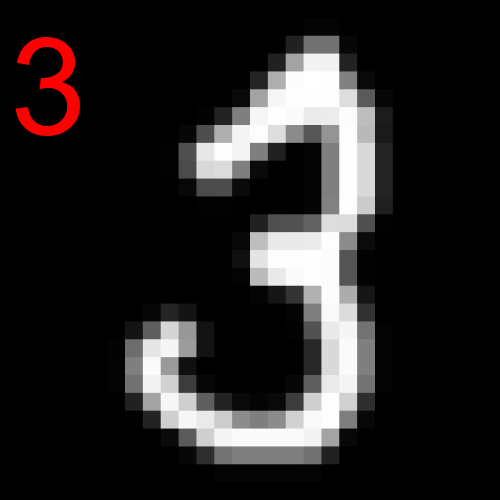

```r
visualize_character <- function(index) {
  img_arr <- array(test_img[index,], c(28, 28, 1))
  img_magick <- magick::image_read(img_arr / 255) %>%
    magick::image_scale("500x500") %>%
    image_annotate(test_img_labels[index], location = geometry_point(10, 10), size = 137, color = "red")
  return(img_magick)
}

visualize_character(10)
```

## 2.2 EMNIST Matlab GIF 시각화

`image_read() %>% image_join() %>% image_animate()` 작업흐름을 통해서 10,000개 손글씨 이미지에서 임으로 100개를 추출하여 정답(`label`)과 손글씨 이미지를 Gif 파일로 시각화한다. `trelliscope`으로 시각화한 사례는 [딥러닝: 캡챠(captcha) 깨기](http://statkclee.github.io/deep-learning/r-keras-captcha.html)를 참조한다.

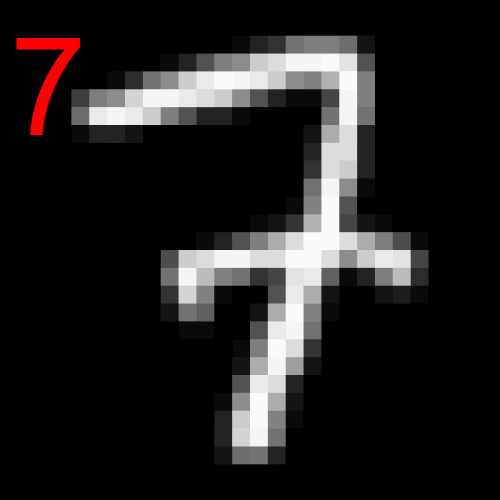

```r
library(tidyverse)

random_img <- sample(1:10000, 100, replace = FALSE)

emnist_random_image <- map(random_img, visualize_character)

emnist_joined <- image_join(emnist_random_image)

image_animate(emnist_joined, fps = 1)
```

## 2.3 EMNIST Matlab GIF 시각화

각각 처리한 이미지를 10개를 뽑아, `image_join()` 함수로 붙이고 나서, `image_append()` 하나로 쭉 이어 붙인다.

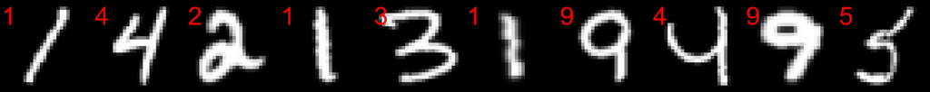

```r
random_img <- sample(1:10000, 10, replace = FALSE)

emnist_random_image <- map(random_img, visualize_character)

image_join(emnist_random_image) %>%
  image_append(stack = FALSE)
```

# 3 `trelliscope` 작은 창

먼저 `MATLAB` 객체를 R 배열(Array) 객체로 변환시키고 이를 `Magick` 객체로 변환시킨 후에 `PNG` 파일로 저장시킨다.

```r
save_image <- function(index) {
  img_arr <- array(test_img[index,], c(28, 28, 1))
  img_magick <- magick::image_read(img_arr / 255) %>%
    magick::image_scale("500x500") %>%
    image_annotate(test_img_labels[index], location = geometry_point(10, 10), size = 137, color = "red")

  image_write(img_magick, glue::glue("data/mnist/image_{index}.png"))
}

save_random_img <- sample(1:10000, 10, replace = FALSE) # 9683 4879 6692 5490 3315 5476 3003 2444 5421 7476

map(save_random_img, save_image)
```

```r
list.files("data/mnist/")
```

```
 [1] "image_2444.png" "image_3003.png" "image_3315.png" "image_4879.png"
 [5] "image_5421.png" "image_5476.png" "image_5490.png" "image_6692.png"
 [9] "image_7476.png" "image_9683.png"
```

다음으로 이를 `trellisocpe`으로 불러 읽어들여 시각화한다. 이를 위해서 먼저 데이터프레임을 준비한다.

```r
library(glue)

file_names <- list.files("data/mnist/")

mnist_df <- tibble(random = c(9683L, 4879L, 6692L, 5490L, 3315L, 5476L, 3003L, 2444L, 5421L, 7476L),
                   label = test_img_labels[c(9683L, 4879L, 6692L, 5490L, 3315L, 5476L, 3003L, 2444L, 5421L, 7476L)],
                   image = glue("data/mnist/image_{random}.png"))

mnist_df
```

```
# A tibble: 10 x 3
   random label image
    <int> <dbl> <glue>
 1   9683     5 data/mnist/image_9683.png
 2   4879     5 data/mnist/image_4879.png
 3   6692     6 data/mnist/image_6692.png
 4   5490     2 data/mnist/image_5490.png
 5   3315     0 data/mnist/image_3315.png
 6   5476     9 data/mnist/image_5476.png
 7   3003     8 data/mnist/image_3003.png
 8   2444     4 data/mnist/image_2444.png
 9   5421     7 data/mnist/image_5421.png
10   7476     8 data/mnist/image_7476.png
```

이제 시각화를 해보자.

```r
library(trelliscopejs)

mnist_df <- mnist_df %>%
  mutate(panel = img_panel_local(image))

trelliscope(mnist_df, name = "mnist",
            nrow = 2, ncol=5,
            state = list(labels = c("label")),
            path="mnist")
```

[interactive chart not shown]

1. Cohen G, Afshar S, Tapson J, Schaik A van. EMNIST: An extension of mnist to handwritten letters. arXiv preprint arXiv:170205373. 2017.